# Numerical Methods and Optimization

Biao Zhang

November 22th, 2021

## Please do NOT share the questions with anyone who are not enrolled in this class. Please do NOT share your code with anyone when you are enrolled in this class. They will be considered as academic misconduct.

1.(4 points) Do you still remember the value of $\sum_{i=0}^\infty \frac{1}{i!}$? Please evaluate it within $10^6$ iterations with precision $\epsilon = 10^{-12}$, and compare it with the theoretical value e.

```r
iter.max.factorial = 10^6
eps.factorial = 1e-12
sum.factorial.old = 0
change.factorial = 1000
iter.factorial = 0
while(change.factorial>eps.factorial&iter.factorial<iter.max.factorial){
  sum.factorial = sum.factorial.old + 1/factorial(iter.factorial) # update the sum
  change.factorial= abs(sum.factorial-sum.factorial.old) # calculate the stopping criterion
  iter.factorial=iter.factorial+1 # update the iteration
  sum.factorial.old = sum.factorial # update the baseline
}
```

The following code report the results.

```r
if(iter.factorial==iter.max.factorial)  print(paste0('The sequence does not converge in ',iter.max.factorial,' iterations!'))
if(change.factorial<eps.factorial) print(paste0('The seuence converges at value ',sum.factorial,' at iteration ',iter.factorial,'.'))
```

```
## [1] "The seuence converges at value 2.71828182845899 at iteration 16."
```

```r
exp(1)
```

```
## [1] 2.718282
```

2. (4 points) Let us reconsider the p-series $\sum_{n=1}^\infty \frac{1}{n^p}$. When $p=1$, does it converge? It turns out that it does not, and as $k$ increases, $\sum_{n=1}^k \frac{1}{n}$ is getting closer to $ln(k)+\gamma$ where $\gamma\approx 0.577215664901532\ldots$ is the Euler-Mascheroni constant. Please use what you have learned in this question to write a program to approximate $\gamma$ with precision $\epsilon=10^{-12}$, and within $10^10$ iterations.

```r
iter.max = 10^10
eps = 1e-12
sum.harmonic.old = 0
change.harmonic = 1000
iter = 0
while(change.harmonic>eps&iter<iter.max){
  sum.harmonic = sum.harmonic.old + sum(1/(iter+c(1:10^6)))
  change.harmonic= abs(sum.harmonic-sum.harmonic.old)
  iter=iter+10^6
  sum.harmonic.old = sum.harmonic
}
```

The following code report the results.

```r
sum.harmonic - log(iter)
```

```
## [1] 0.5772157
```

3. (5 points) Consider a class of truncated normal distribution. That is, the shape of their pdfs look like those for normal, but their supported is limited to an interval $[a,b]$. The pdf of a truncated normal distribution on interval $(a,b)$ is $\frac{\phi(x;\mu,\sigma)}{\Phi(b;\mu,\sigma)-\Phi(a;\mu,\sigma)}$ where $\phi(x;\mu,\sigma)$ and $\Phi(x;\mu,\sigma)$ are the pdf and cdf of the un-truncated normal $N(\mu,\sigma)$. Now consider $X\sim Truncated-Normal (\mu=3,\sigma=1,a=0,b=\infty)$ please use R function integrate() to calculate the following
1. $P(X\leq 2)$
2. $E(X)$
3. $Var(X)$

Are they still the same as for the un-truncated version? Do you expect what you see here?

```r
truncated.moments.df = function(x, mean, std, a, b, p) {
  ifelse(x >= 0,x^p*dnorm(x, mean = mean, sd = std)/(pnorm(b, mean = mean, sd = std) - pnorm(a, mean = mean, sd = std)),0)
}
integrate(truncated.moments.df, 0, 2, mean = 3, std = 1, a = 0, b = Inf, p = 0)
```

```
## 0.157518 with absolute error < 1.7e-15
```

```r
(EX = integrate(truncated.moments.df, 0, Inf, mean = 3, std = 1, a = 0, b = Inf, p = 1))
```

```
## 3.004438 with absolute error < 0.00033
```

```r
EX.2 = integrate(truncated.moments.df, 0, Inf, mean = 3, std = 1, a = 0, b = Inf, p = 2)
EX.2$value - (EX$value)^2
```

```
## [1] 0.9866668
```

There are little differences on mean and variance in comparison with what we expect. Since now the normal is truncated at 0, as it is showed in the following plot, it is not surprise.

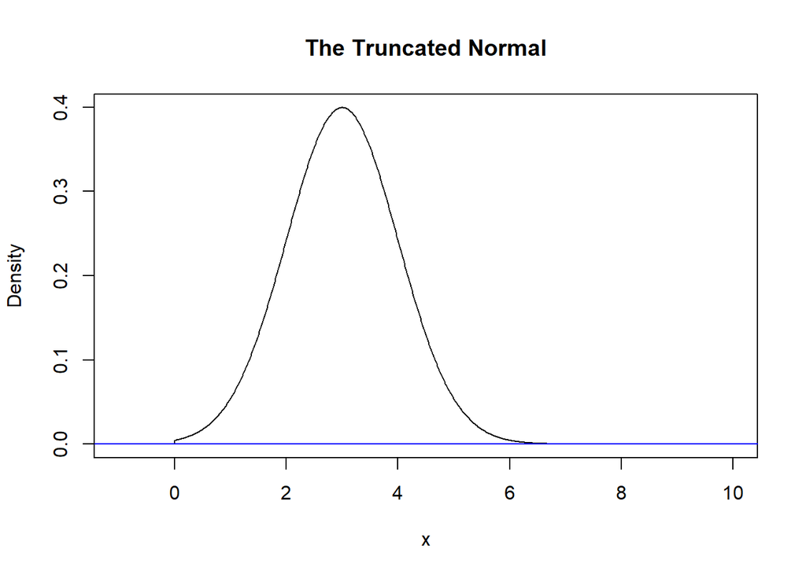

```r
plot(seq(-1,10,.01),truncated.moments.df(seq(-1,10,.01), mean = 3, std = 1, a = 0, b = Inf, p = 0),type = "l",xlab = "x", ylab = "Density", main = "The Truncated Normal")
abline(h = 0, col = "blue")
```

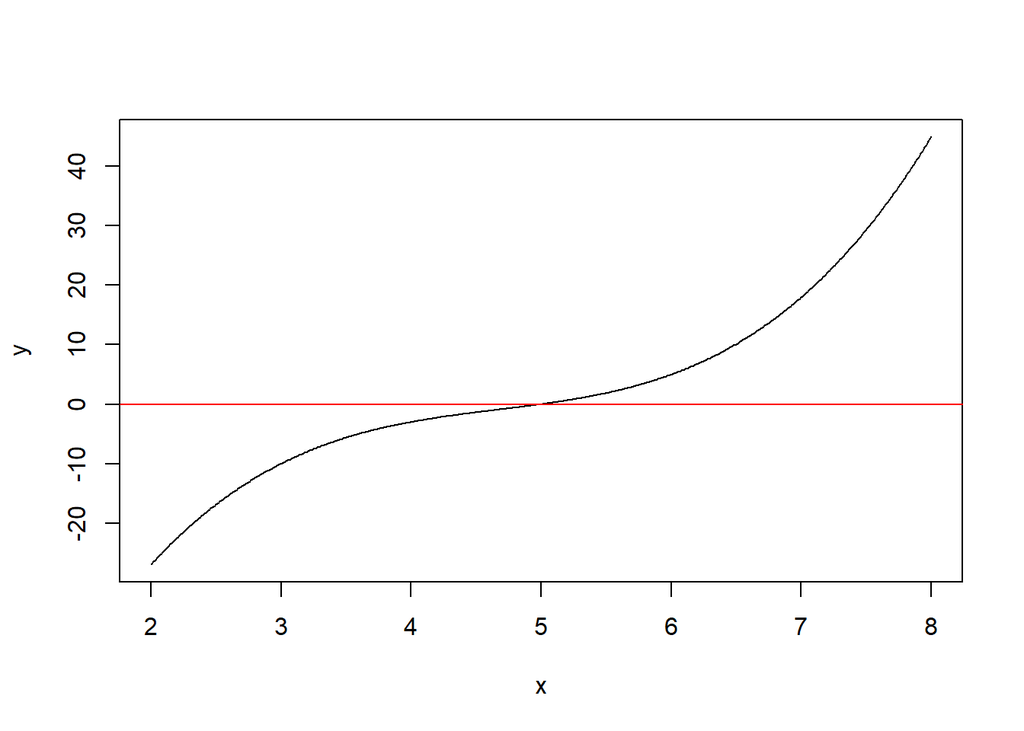

```r
f.cubic = function(x) x^3-14*x^2+68*x-115
f.cubic.gradient = function(x) 3*x^2-28*x+68
plot(seq(2,8,.01),f.cubic(seq(2,8,.01)),type = "l",xlab = "x",ylab = "y")
abline(h = 0, col = "red")
```

```r
eps = 1e-9 #Attention! eps cannot be set too small. If we use 1e-12 as indicated
           #by the question. Later in question5, the denominator f(xk) - f(xk1)
           #in secant method will generate NaN to stop the process.
iter.max = 200
update.newton <- function(xk,f,f.gradient){
  x.next = xk-f(xk)/f.gradient(xk)
  return(x.next)
}

iter.Q4=0
err.x.Q4=1
x.init.Q4=10
while(err.x.Q4>eps&iter.Q4<iter.max){
  x.new.Q4 = update.newton(xk=x.init.Q4, f=f.cubic,f.gradient = f.cubic.gradient)
  err.x.Q4 = abs(x.new.Q4-x.init.Q4)
  iter.Q4=iter.Q4+1
  x.init.Q4=x.new.Q4
}
```

The following code report the results.

```r
if(iter.Q4==iter.max)  print(paste0('The algorithm does not converge in ',iter.max,' iterations!'))
if(err.x.Q4<eps) print(paste0('The algorithm converges at x= ',x.new.Q4,' at iteration ',iter.Q4,'.'))
```

```
## [1] "The algorithm converges at x= 5.00000000000001 at iteration 9."
```

5.(5 points) Please re-do the previous question using secant method. Note that it needs two initial points to calculate the initial slope. For the previous quesiton, let say $x_0^{(0)}=10$ and $x_0^{(1)}=9$. Does it use more or less iterations than Newton’s method?

```r
update.secant <- function(xk,xk1,f){
  x.next = xk-f(xk)*(xk-xk1)/(f(xk)-f(xk1))
  return(x.next)
}

iter.Q5=0
err.x.Q5=1
x.init0.Q5=9
x.init1.Q5=10

while(err.x.Q5>eps&iter.Q5<iter.max){
  x.new.Q5 = update.secant(xk=x.init0.Q5,xk1=x.init1.Q5, f=f.cubic)
  err.x.Q5 = abs(x.new.Q5-x.init1.Q5)
  iter.Q5=iter.Q5+1
  x.init1.Q5=x.init0.Q5
  x.init0.Q5=x.new.Q5
}
```

The following code report the results.

```r
if(iter.Q5==iter.max)  print(paste0('The algorithm does not converge in ',iter.max,' iterations!'))
if(err.x.Q5<eps) print(paste0('The algorithm converges at x= ',x.new.Q5,' at iteration ',iter.Q5,'.'))
```

```
## [1] "The algorithm converges at x= 5 at iteration 12."
```

It uses more iterations than Newton’s Method, since the derivative is approximated.